# Sapling PIRI GLMM

Kathleen Stutzman

2024-01-04

## Introduction:

This script, originally written as an R script, will be much more readable as an R Markdown. Therefore, I am translating it into a markdown file.

# Pitch Pine Sapling GLMM code

Libraries:

```r
# libraries -------------------
library(dplyr)
library(tidyverse)
library(ggplot2)
library(lme4)
library(lmerTest)
library(glmmTMB)
library(TMB)
library(emmeans)
library(DHARMa)
```

Set working directory

```r
knitr::opts_knit$set(root.dir = '/Users/user/Desktop/Data/Regen_RProj/')
```

Functions:

```r
# functions -------------------
```

Global variables:

```r
file_folder_SA <- "CleanData/sapling_CSV/"

options(scipen = 999) #to display actual values

file_names_SA <- list.files(path=file_folder_SA)
```

For loop to read in files:

```r
for (i in seq_along(file_names_SA)) {
  assign(paste0(file_names_SA[i], i),
         read.csv(paste0(file_folder_SA, file_names_SA[i])))
}

# Adding treatment types -------------------
SA_Control_Data.csv1$Treat_Type <- "Control"
SA_Fall_Burn_Data.csv2$Treat_Type <- "FallRx"
SA_Mow_Burn_Data.csv3$Treat_Type <- "MowRx"
SA_Spring_Burn_Data.csv4$Treat_Type <- "SpringRx"
SA_Thinned_Data.csv5$Treat_Type <- "Harvest"

# merge into one data set -------------------
sapling <- rbind(SA_Control_Data.csv1,
                 SA_Fall_Burn_Data.csv2,
                 SA_Mow_Burn_Data.csv3,
                 SA_Spring_Burn_Data.csv4,
                 SA_Thinned_Data.csv5)


# remove data sets to keep environment clean-------------------
rm(SA_Control_Data.csv1,
   SA_Fall_Burn_Data.csv2,
   SA_Mow_Burn_Data.csv3,
   SA_Spring_Burn_Data.csv4,
   SA_Thinned_Data.csv5)
```

Creating groupings of species: PIRI, Shrub Oak, & Other:

```r
sapling$Species_Groups <- NA

# PIRI
sapling$Species_Groups <- ifelse(sapling$Species_Code == 'PIRI', 'PIRI', sapling$Species_Groups)

# Shrub Oak
sapling$Species_Groups <- ifelse(sapling$Species_Code %in% c('QUIL','QUPR'), 'Shrub Oak', sapling$Species_Groups)

#Other
sapling$Species_Groups <- ifelse(sapling$Species_Code %in% c('ACRU', 'BEPO', 'QUCO', 'QUAL', 'QUVE', 'QUST', 'QURU', 'QUPR', 'PRSE', 'FRPE', 'PRVI', 'PODE', 'POGR', 'SAAL', 'AMSP', 'FAGR', 'NYSY', 'ACPE', 'ACNE', 'MOSP', 'POTR', 'PRSP', 'PIST', 'ABBA', 'FRAL', 'ROPS', 'RHCA', 'ELUM', 'BELE'), 'Other', sapling$Species_Groups)


# now to check all have been assigned -------------------
check_sa <- sapling %>%
  filter(if_any(Species_Groups, is.na))

# there are 724 plots that do not have saplings recorded -------------------

rm(check_sa)
```

Manipulate data to create a complete dataset, where implied zeros are now express and combined species groups totals are counted as one:

```r
sapling2 <- sapling %>%
  select(Region,
         Treat_Type,
         Site,
         Plot_No,
         Species_Groups,
         DBH.cm.)

# we should have just tallied amounts instead of recording DBH, so now to convert to tally
sapling2$Tally <- NA

sapling2$Tally <- ifelse(sapling2$DBH.cm. >= 2.5, 1, sapling2$Tally)

sapling2$Tally <- ifelse(sapling2$DBH.cm. == 0, 0, sapling2$Tally)

# check to see all have been assigned -------------------
check_sapling <- sapling2 %>%
  filter(if_any(Tally, is.na))

rm(check_sapling)

# add duplicates by plot and filter it down -------------------
sapling3 <- sapling2 %>%
  select(Region,
         Treat_Type,
         Site,
         Plot_No,
         Species_Groups,
         Tally)

#check for correct number of plots (1001)
n_distinct(sapling3$Plot_No)
```

```
## [1] 1001
```

```r
# split data set to use complete function
sapling_meta <- sapling3 %>%
  select(Region, Treat_Type, Site, Plot_No) %>%
  distinct(Plot_No, .keep_all = TRUE)

sapling_plot <- sapling3 %>%
  select(Plot_No, Species_Groups, Tally)

#duplicates of "other need to be combined
sapling_plot1 <- sapling_plot %>%
  group_by(Plot_No, Species_Groups) %>%
  summarise(Total_Tally = sum(Tally)) %>%
  ungroup()
sapling_plot2 <- sapling_plot1 %>%
  complete(Plot_No, Species_Groups, fill = list(Total_Tally = 0))

sapling_NA <- sapling_plot2[complete.cases(sapling_plot2),]

sapling_merge <- merge(sapling_meta, sapling_NA, by= "Plot_No")

# now remove datasets no longer needed to keep envr clean -------------------
rm(sapling_meta,
   sapling_plot,
   sapling_plot1,
   sapling_plot2,
   sapling2,
   sapling3,
   sapling_NA)
```

Now looking just at PIRI:

```r
# filter for just piri -------------------
sapling_PIRI <- sapling_merge %>%
  filter(Species_Groups == "PIRI") %>%
  arrange(Treat_Type)
# PIRI saplings are only in 50 of the 1001 plots and mostly in control sites....


# now to make the explanatory variables factors
sapling_PIRI$Treat_Type = factor(sapling_PIRI$Treat_Type,
                              levels = unique(sapling_PIRI$Treat_Type))

sapling_PIRI$Region = factor(sapling_PIRI$Region,
                          levels = unique(sapling_PIRI$Region))

sapling_PIRI$Site = factor(sapling_PIRI$Site,
                        levels = unique(sapling_PIRI$Site))
```

Import time since data and add it to the PIRI dataset

```r
time_since <- read_csv("CleanData/Treat_Year_Data.csv")
sapling_PIRI2 <- merge(sapling_PIRI, time_since, by = 'Site')
#log transform time from treatment data
sapling_PIRI2$l.TFT <- log(sapling_PIRI2$Time_from_Treat)
```

Run the ‘Add_BA’ script and merge with dataset (should probably clean this script)

```r
source("Scripts/Add_BA.R")
```

```r
# merge with ls dataset -------------------
sa.merge1 <- merge(sapling_PIRI2, prism_BA, by = 'Plot_No')
```

Run ‘Ground_Data.R’ script and add it to PIRI dataset (should probably clean this as well)

```r
source("Scripts/Ground_Data.R")

# merge with ls dataset -------------------
sa_alldata <- merge(sa.merge1, ground3, by = 'Plot_No')

rm(#sa.merge1, keeping this data set to be able to run models that operate on all the observations, as LD not important
   sapling_PIRI2)
```

Hidden below are models with convergence problems:

Models that converge:

```r
sa.p3 <- glmer(Total_Tally~Treat_Type + avgLD_l + (1|Site/Plot_No) + offset(l.TFT),
               data = sa_alldata,
               family = poisson)
summary(sa.p3) #first model that didn't fail to converge, AIC is 213.6
```

```
## Generalized linear mixed model fit by maximum likelihood (Laplace
##   Approximation) [glmerMod]
##  Family: poisson  ( log )
## Formula:
## Total_Tally ~ Treat_Type + avgLD_l + (1 | Site/Plot_No) + offset(l.TFT)
##    Data: sa_alldata
##
##      AIC      BIC   logLik deviance df.resid
##    213.6    247.1    -98.8    197.6      479
##
## Scaled residuals:
##      Min       1Q   Median       3Q      Max
## -0.05832 -0.02593 -0.02003 -0.01271  0.24879
##
## Random effects:
##  Groups       Name        Variance Std.Dev.
##  Plot_No:Site (Intercept) 39.285   6.268
##  Site         (Intercept)  1.274   1.129
## Number of obs: 487, groups:  Plot_No:Site, 487; Site, 46
##
## Fixed effects:
##                    Estimate Std. Error z value    Pr(>|z|)
## (Intercept)        -11.1956     2.1861  -5.121 0.000000304 ***
## Treat_TypeFallRx     1.1164     1.3999   0.798       0.425
## Treat_TypeHarvest    1.2403     1.7614   0.704       0.481
## Treat_TypeMowRx      1.5424     1.2850   1.200       0.230
## Treat_TypeSpringRx   0.5546     2.3300   0.238       0.812
## avgLD_l              0.2974     1.0833   0.275       0.784
## ---
## Signif. codes:  0 '***' 0.001 '**' 0.01 '*' 0.05 '.' 0.1 ' ' 1
##
## Correlation of Fixed Effects:
##             (Intr) Tr_TFR Trt_TH Tr_TMR Tr_TSR
## Trt_TypFllR -0.250
## Trt_TypHrvs -0.123  0.255
## Trt_TypMwRx -0.495  0.364  0.265
## Trt_TypSprR -0.174  0.202  0.160  0.233
## avgLD_l     -0.846  0.033 -0.065  0.295  0.035
```

```r
######## this is the best model
sa.p4 <- glmer(Total_Tally~Treat_Type + (1|Site/Plot_No) + offset(l.TFT),
               data = sa_alldata,
               family = poisson)
summary(sa.p4) #AIC is 211.7
```

```
## Generalized linear mixed model fit by maximum likelihood (Laplace
##   Approximation) [glmerMod]
##  Family: poisson  ( log )
## Formula: Total_Tally ~ Treat_Type + (1 | Site/Plot_No) + offset(l.TFT)
##    Data: sa_alldata
##
##      AIC      BIC   logLik deviance df.resid
##    211.7    241.0    -98.9    197.7      480
##
## Scaled residuals:
##      Min       1Q   Median       3Q      Max
## -0.05426 -0.02632 -0.01984 -0.01368  0.25070
##
## Random effects:
##  Groups       Name        Variance Std.Dev.
##  Plot_No:Site (Intercept) 39.406   6.277
##  Site         (Intercept)  1.356   1.164
## Number of obs: 487, groups:  Plot_No:Site, 487; Site, 46
##
## Fixed effects:
##                    Estimate Std. Error z value            Pr(>|z|)
## (Intercept)        -10.7049     1.1656  -9.184 <0.0000000000000002 ***
## Treat_TypeFallRx     1.1057     1.4051   0.787               0.431
## Treat_TypeHarvest    1.2732     1.7608   0.723               0.470
## Treat_TypeMowRx      1.4382     1.2284   1.171               0.242
## Treat_TypeSpringRx   0.5267     2.3203   0.227               0.820
## ---
## Signif. codes:  0 '***' 0.001 '**' 0.01 '*' 0.05 '.' 0.1 ' ' 1
##
## Correlation of Fixed Effects:
##             (Intr) Tr_TFR Trt_TH Tr_TMR
## Trt_TypFllR -0.416
## Trt_TypHrvs -0.337  0.257
## Trt_TypMwRx -0.483  0.369  0.299
## Trt_TypSprR -0.274  0.202  0.164  0.236
```

```r
# would like to try this model again, but with all the data (as model is not using veg/soil data, which cuts sample size in half)
sa.p5 <- glmer(Total_Tally~Treat_Type + (1|Site/Plot_No) + offset(l.TFT),
               data = sa.merge1,
               family = poisson)
summary(sa.p5) #it fails to converge with all data
```

```
## Generalized linear mixed model fit by maximum likelihood (Laplace
##   Approximation) [glmerMod]
##  Family: poisson  ( log )
## Formula: Total_Tally ~ Treat_Type + (1 | Site/Plot_No) + offset(l.TFT)
##    Data: sa.merge1
##
##      AIC      BIC   logLik deviance df.resid
##    409.1    443.3   -197.6    395.1      971
##
## Scaled residuals:
##      Min       1Q   Median       3Q      Max
## -0.10255 -0.03118 -0.02089 -0.01544  0.34070
##
## Random effects:
##  Groups       Name        Variance Std.Dev.
##  Plot_No:Site (Intercept) 30.25    5.500
##  Site         (Intercept)  1.05    1.025
## Number of obs: 978, groups:  Plot_No:Site, 978; Site, 46
##
## Fixed effects:
##                    Estimate Std. Error z value            Pr(>|z|)
## (Intercept)        -10.1082     0.8066 -12.532 <0.0000000000000002 ***
## Treat_TypeFallRx     0.6807     0.9831   0.692               0.489
## Treat_TypeHarvest    0.7829     1.2759   0.614               0.539
## Treat_TypeMowRx      0.7695     0.9244   0.832               0.405
## Treat_TypeSpringRx   0.7053     1.2761   0.553               0.580
## ---
## Signif. codes:  0 '***' 0.001 '**' 0.01 '*' 0.05 '.' 0.1 ' ' 1
##
## Correlation of Fixed Effects:
##             (Intr) Tr_TFR Trt_TH Tr_TMR
## Trt_TypFllR -0.374
## Trt_TypHrvs -0.280  0.214
## Trt_TypMwRx -0.393  0.303  0.236
## Trt_TypSprR -0.293  0.223  0.174  0.249
## optimizer (Nelder_Mead) convergence code: 0 (OK)
## Model failed to converge with max|grad| = 0.460182 (tol = 0.002, component 1)
```

```r
rm(sa.pa5)
```

```r
sa.p6 <- glmer(Total_Tally~Treat_Type + (1|Site/Plot_No),
               data = sa_alldata,
               family = poisson)
summary(sa.p6) #AIC is 211.3
```

```
## Generalized linear mixed model fit by maximum likelihood (Laplace
##   Approximation) [glmerMod]
##  Family: poisson  ( log )
## Formula: Total_Tally ~ Treat_Type + (1 | Site/Plot_No)
##    Data: sa_alldata
##
##      AIC      BIC   logLik deviance df.resid
##    211.3    240.7    -98.7    197.3      480
##
## Scaled residuals:
##      Min       1Q   Median       3Q      Max
## -0.05550 -0.02316 -0.01955 -0.01779  0.25184
##
## Random effects:
##  Groups       Name        Variance Std.Dev.
##  Plot_No:Site (Intercept) 38.428   6.199
##  Site         (Intercept)  1.344   1.159
## Number of obs: 487, groups:  Plot_No:Site, 487; Site, 46
##
## Fixed effects:
##                    Estimate Std. Error z value       Pr(>|z|)
## (Intercept)         -7.1731     1.1622  -6.172 0.000000000674 ***
## Treat_TypeFallRx    -0.7014     1.3877  -0.505          0.613
## Treat_TypeHarvest   -0.8685     1.7619  -0.493          0.622
## Treat_TypeMowRx     -0.6757     1.2175  -0.555          0.579
## Treat_TypeSpringRx  -1.9104     2.2622  -0.844          0.398
## ---
## Signif. codes:  0 '***' 0.001 '**' 0.01 '*' 0.05 '.' 0.1 ' ' 1
##
## Correlation of Fixed Effects:
##             (Intr) Tr_TFR Trt_TH Tr_TMR
## Trt_TypFllR -0.420
## Trt_TypHrvs -0.328  0.255
## Trt_TypMwRx -0.482  0.372  0.292
## Trt_TypSprR -0.279  0.209  0.164  0.241
```

```r
sa.p7 <- glmer(Total_Tally~Treat_Type + l.BA_piri + (1|Site/Plot_No) + offset(l.TFT),
               data = sa_alldata,
               family = poisson)
summary(sa.p7)
```

```
## Generalized linear mixed model fit by maximum likelihood (Laplace
##   Approximation) [glmerMod]
##  Family: poisson  ( log )
## Formula:
## Total_Tally ~ Treat_Type + l.BA_piri + (1 | Site/Plot_No) + offset(l.TFT)
##    Data: sa_alldata
##
##      AIC      BIC   logLik deviance df.resid
##    212.2    245.7    -98.1    196.2      479
##
## Scaled residuals:
##      Min       1Q   Median       3Q      Max
## -0.06612 -0.02846 -0.01872 -0.01104  0.27849
##
## Random effects:
##  Groups       Name        Variance Std.Dev.
##  Plot_No:Site (Intercept) 34.567   5.879
##  Site         (Intercept)  1.454   1.206
## Number of obs: 487, groups:  Plot_No:Site, 487; Site, 46
##
## Fixed effects:
##                    Estimate Std. Error z value     Pr(>|z|)
## (Intercept)        -12.5477     2.2626  -5.546 0.0000000293 ***
## Treat_TypeFallRx     1.1301     1.3932   0.811        0.417
## Treat_TypeHarvest    1.6050     1.7212   0.932        0.351
## Treat_TypeMowRx      2.0511     1.2910   1.589        0.112
## Treat_TypeSpringRx   0.6462     2.2404   0.288        0.773
## l.BA_piri            0.7266     0.6522   1.114        0.265
## ---
## Signif. codes:  0 '***' 0.001 '**' 0.01 '*' 0.05 '.' 0.1 ' ' 1
##
## Correlation of Fixed Effects:
##             (Intr) Tr_TFR Trt_TH Tr_TMR Tr_TSR
## Trt_TypFllR -0.210
## Trt_TypHrvs -0.305  0.249
## Trt_TypMwRx -0.542  0.337  0.333
## Trt_TypSprR -0.172  0.197  0.166  0.232
## l.BA_piri   -0.856  0.005  0.164  0.374  0.042
```

Test models:

```r
library(lmtest)
lrtest(sa.p4, sa.p6) #same p-value as the offset in other tests, wonder what that's about
```

```
## Likelihood ratio test
##
## Model 1: Total_Tally ~ Treat_Type + (1 | Site/Plot_No) + offset(l.TFT)
## Model 2: Total_Tally ~ Treat_Type + (1 | Site/Plot_No)
##   #Df  LogLik Df  Chisq            Pr(>Chisq)
## 1   7 -98.859
## 2   7 -98.673  0 0.3709 < 0.00000000000000022 ***
## ---
## Signif. codes:  0 '***' 0.001 '**' 0.01 '*' 0.05 '.' 0.1 ' ' 1
```

```r
lrtest(sa.p4, sa.p7) #p = .2, not worth the l.BA_piri
```

```
## Likelihood ratio test
##
## Model 1: Total_Tally ~ Treat_Type + (1 | Site/Plot_No) + offset(l.TFT)
## Model 2: Total_Tally ~ Treat_Type + l.BA_piri + (1 | Site/Plot_No) + offset(l.TFT)
##   #Df  LogLik Df  Chisq Pr(>Chisq)
## 1   7 -98.859
## 2   8 -98.100  1 1.5163     0.2182
```

```r
rm(sa.p3, sa.p6, sa.p7)
```

Run DHARMa package to check model fit:

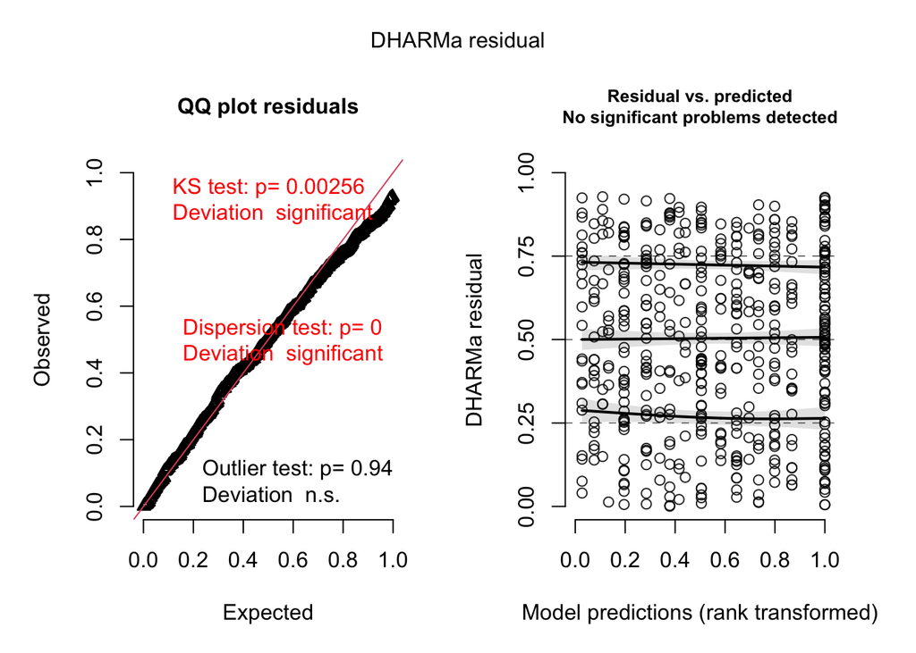

```r
sa.p4_sr <- simulateResiduals(fittedModel = sa.p4, n=1000, plot = TRUE)
```

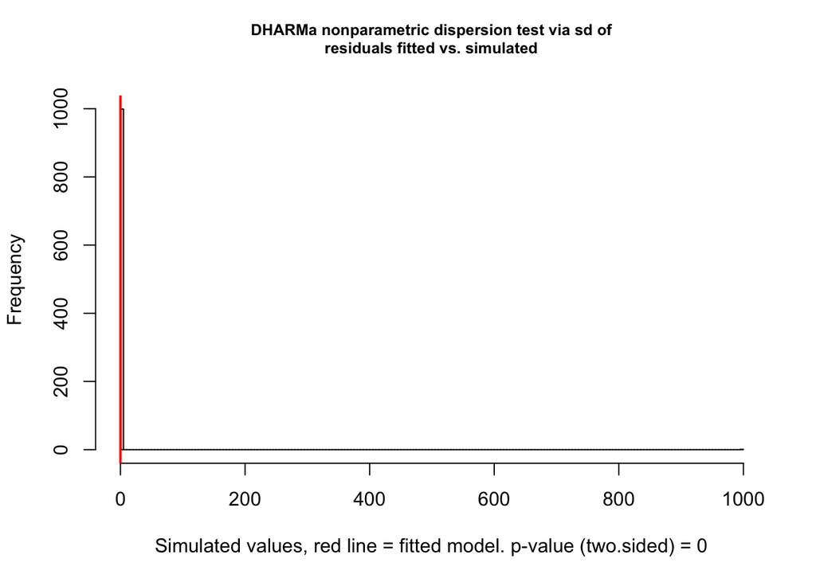

```
##
##  DHARMa nonparametric dispersion test via sd of residuals fitted vs.
##  simulated
##
## data:  simulationOutput
## dispersion = 0.00000000000000020816, p-value < 0.00000000000000022
## alternative hypothesis: two.sided
```

```r
testDispersion(sa.p4_sr)
```

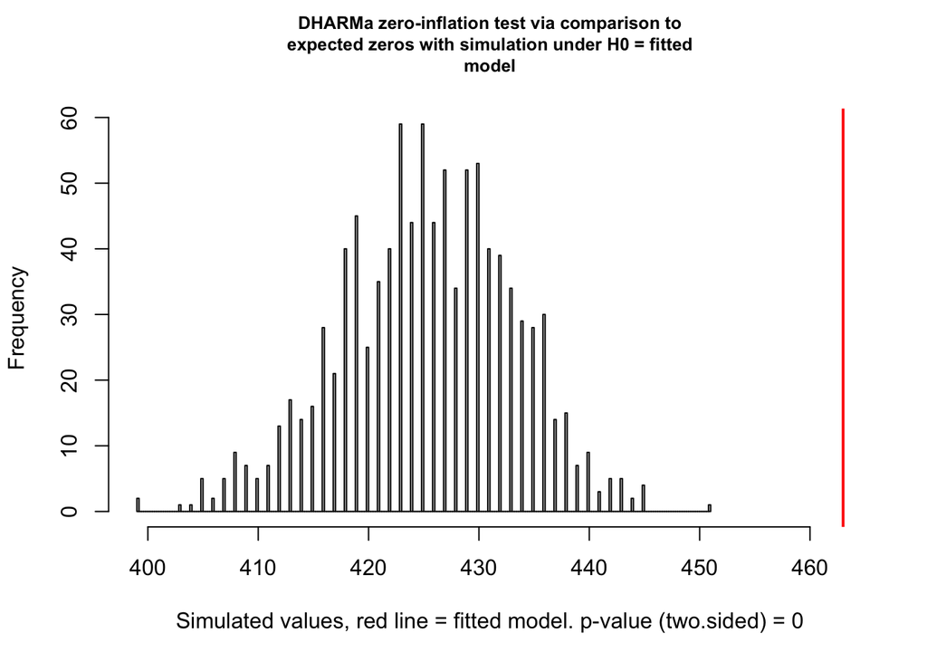

```
##
##  DHARMa zero-inflation test via comparison to expected zeros with
##  simulation under H0 = fitted model
##
## data:  simulationOutput
## ratioObsSim = 1.0884, p-value < 0.00000000000000022
## alternative hypothesis: two.sided
```

```r
testZeroInflation(sa.p4_sr)
```

```r
#no good, model is zero inflated
```

Data is zero inflated. Need to try zero inflated models:

```r
######## this is the best model
sa.zi4 <- glmmTMB(Total_Tally~Treat_Type + (1|Site/Plot_No) + offset(l.TFT),
               data = sa_alldata,
               ziformula=~1,
               family = poisson)
summary(sa.zi4) #AIC is 257.7 - this passes the DHARMa test
```

```
##  Family: poisson  ( log )
## Formula:          Total_Tally ~ Treat_Type + (1 | Site/Plot_No) + offset(l.TFT)
## Zero inflation:               ~1
## Data: sa_alldata
##
##      AIC      BIC   logLik deviance df.resid
##    257.7    291.2   -120.8    241.7      479
##
## Random effects:
##
## Conditional model:
##  Groups       Name        Variance      Std.Dev.
##  Plot_No:Site (Intercept) 0.63728321949 0.79830021
##  Site         (Intercept) 0.00000000498 0.00007057
## Number of obs: 487, groups:  Plot_No:Site, 487; Site, 46
##
## Conditional model:
##                    Estimate Std. Error z value          Pr(>|z|)
## (Intercept)         -3.1017     0.4233  -7.328 0.000000000000234 ***
## Treat_TypeFallRx     0.1476     0.7204   0.205             0.838
## Treat_TypeHarvest    0.6146     0.9135   0.673             0.501
## Treat_TypeMowRx      0.6062     0.6606   0.918             0.359
## Treat_TypeSpringRx  -0.7139     1.1437  -0.624             0.532
## ---
## Signif. codes:  0 '***' 0.001 '**' 0.01 '*' 0.05 '.' 0.1 ' ' 1
##
## Zero-inflation model:
##             Estimate Std. Error z value     Pr(>|z|)
## (Intercept)    1.871      0.337   5.553 0.0000000281 ***
## ---
## Signif. codes:  0 '***' 0.001 '**' 0.01 '*' 0.05 '.' 0.1 ' ' 1
```

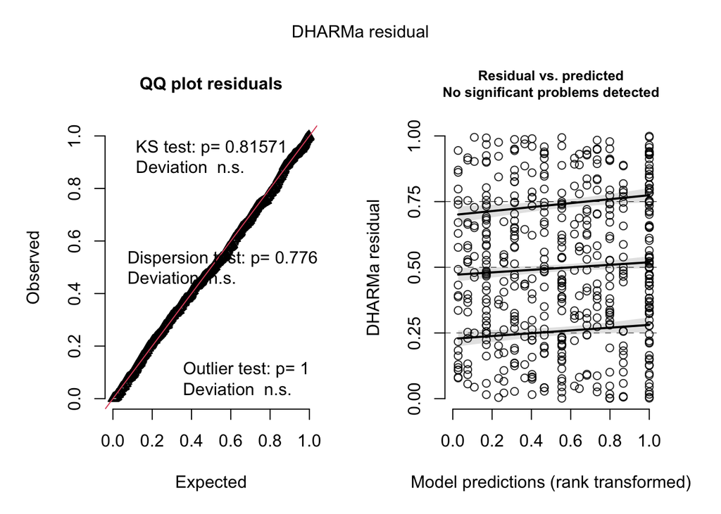

```r
sa.zi4_sr <- simulateResiduals(fittedModel = sa.zi4, n = 1000, plot = TRUE)
```

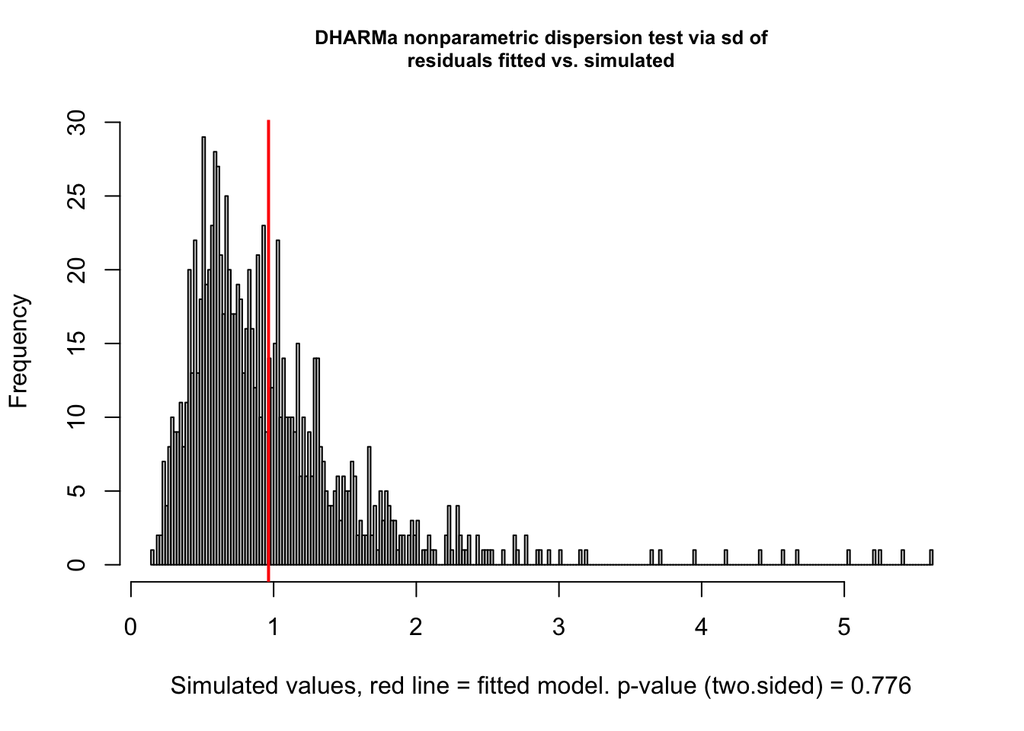

```
##
##  DHARMa nonparametric dispersion test via sd of residuals fitted vs.
##  simulated
##
## data:  simulationOutput
## dispersion = 0.988, p-value = 0.776
## alternative hypothesis: two.sided
```

```r
testDispersion(sa.zi4_sr)# PASSES
```

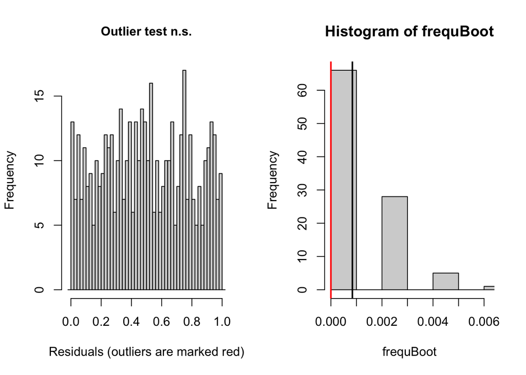

```
##
##  DHARMa bootstrapped outlier test
##
## data:  sa.zi4_sr
## outliers at both margin(s) = 0, observations = 487, p-value = 1
## alternative hypothesis: two.sided
##  percent confidence interval:
##  0.000000000 0.004106776
## sample estimates:
## outlier frequency (expected: 0.000841889117043121 )
##                                                   0
```

```r
testOutliers(sa.zi4_sr)
```

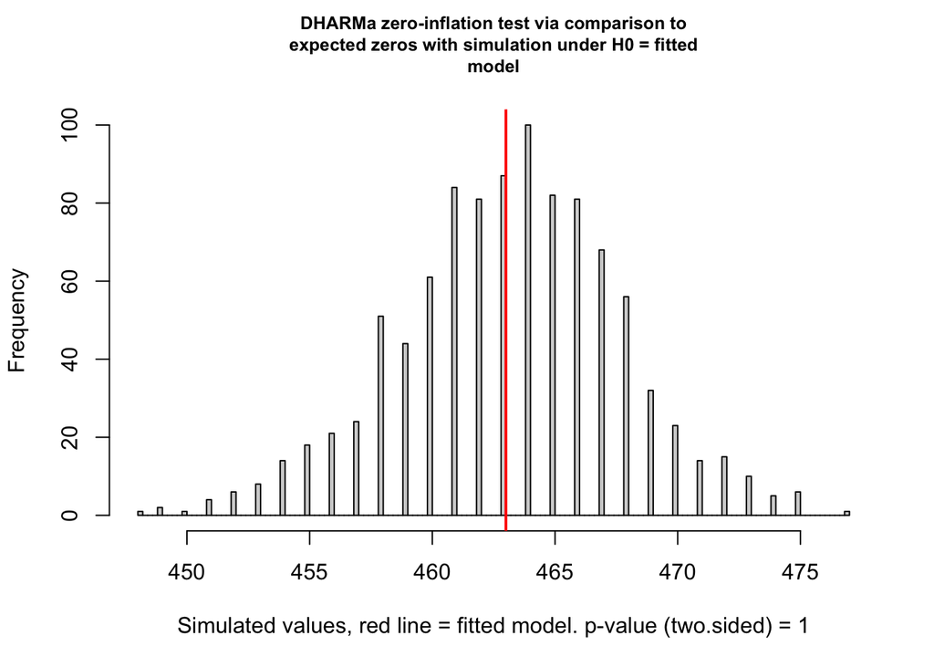

```
##
##  DHARMa zero-inflation test via comparison to expected zeros with
##  simulation under H0 = fitted model
##
## data:  simulationOutput
## ratioObsSim = 0.99951, p-value = 1
## alternative hypothesis: two.sided
```

```r
testZeroInflation(sa.zi4_sr) #looking a lot better
```

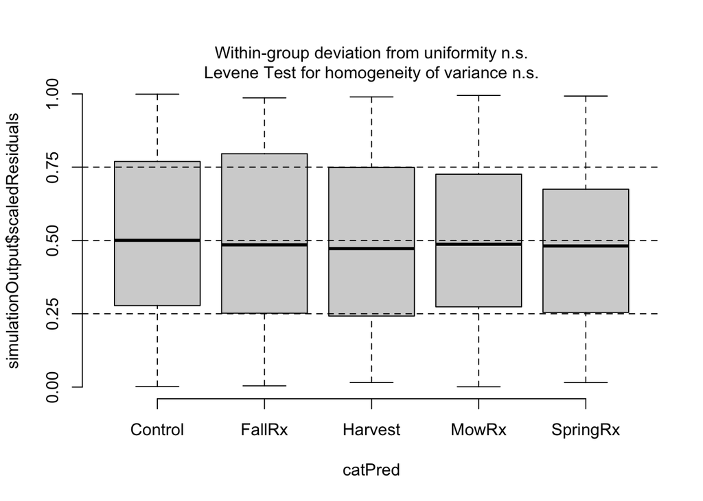

```r
plotResiduals(sa.zi4_sr, sa_alldata$Treat_Type, xlab = "Treatment Type", main=NULL)
```

```r
#plotResiduals(sa.zi4_sr, sa_alldata$Site, xlab = "Site", main=NULL)

# would like to try this model again, but with all the data
sa.zi9 <- glmmTMB(Total_Tally~Treat_Type + (1|Site/Plot_No) + offset(l.TFT),
                  data = sa.merge1,
                  ziformula=~1,
                  family = poisson)
summary(sa.zi9) #AIC is 411.1 - lets check with dharma
```

```
##  Family: poisson  ( log )
## Formula:          Total_Tally ~ Treat_Type + (1 | Site/Plot_No) + offset(l.TFT)
## Zero inflation:               ~1
## Data: sa.merge1
##
##      AIC      BIC   logLik deviance df.resid
##    411.1    450.1   -197.5    395.1      970
##
## Random effects:
##
## Conditional model:
##  Groups       Name        Variance Std.Dev.
##  Plot_No:Site (Intercept) 31.926   5.65
##  Site         (Intercept)  1.167   1.08
## Number of obs: 978, groups:  Plot_No:Site, 978; Site, 46
##
## Conditional model:
##                    Estimate Std. Error z value            Pr(>|z|)
## (Intercept)        -10.3270     0.8468 -12.195 <0.0000000000000002 ***
## Treat_TypeFallRx     0.7000     1.0391   0.674               0.501
## Treat_TypeHarvest    0.8866     1.3177   0.673               0.501
## Treat_TypeMowRx      0.8676     0.9619   0.902               0.367
## Treat_TypeSpringRx   0.8259     1.3131   0.629               0.529
## ---
## Signif. codes:  0 '***' 0.001 '**' 0.01 '*' 0.05 '.' 0.1 ' ' 1
##
## Zero-inflation model:
##             Estimate Std. Error z value Pr(>|z|)
## (Intercept)   -21.61    7938.80  -0.003    0.998
```

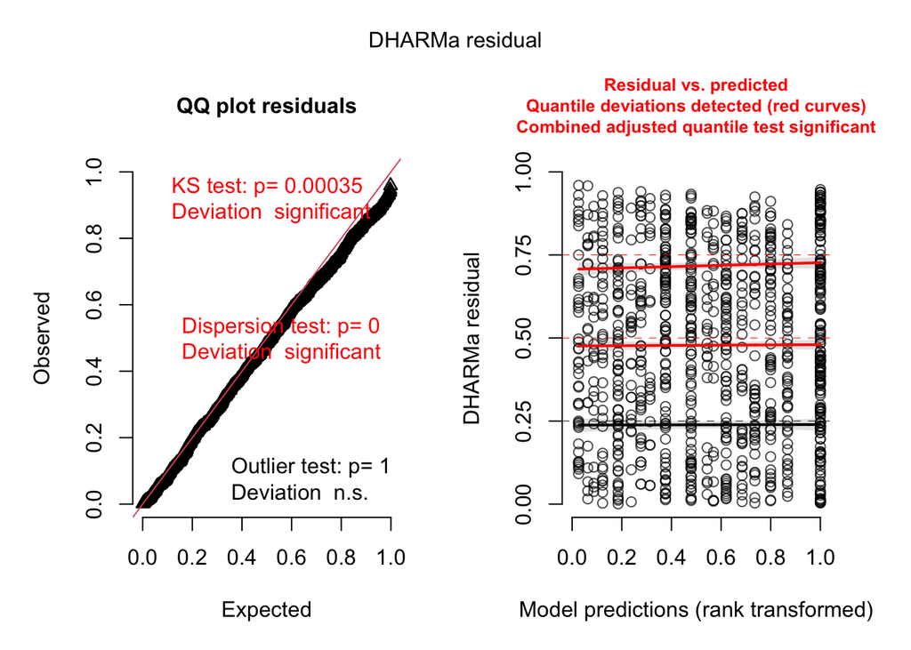

```r
sa.zi9_sr <- simulateResiduals(fittedModel = sa.zi9, n = 1000, plot = TRUE) #significant differences
```

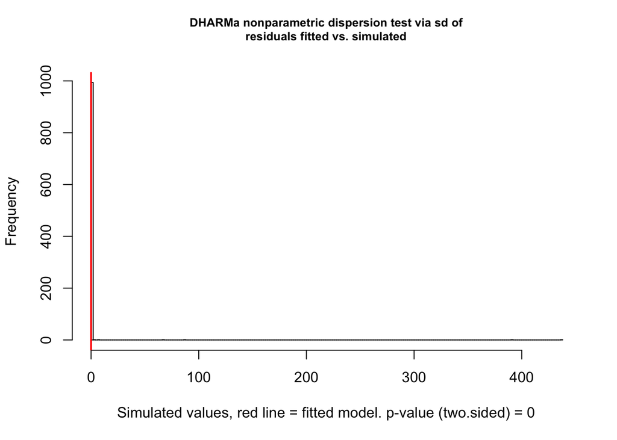

```
##
##  DHARMa nonparametric dispersion test via sd of residuals fitted vs.
##  simulated
##
## data:  simulationOutput
## dispersion = 0.00000000000070409, p-value < 0.00000000000000022
## alternative hypothesis: two.sided
```

```r
testDispersion(sa.zi9_sr)# does not pass
```